# Climate Change is Making an Impact - Do We Want to Act?

Emily Cole

November 1, 2018

Climate change is already having a dramatic impact on our world, but many still do not see it as a crucial issue. I decided to create three graphs to illustrate the change already taking place and people’s opinions of the issue and a potential response. I used the Wall Street Journal theme because I liked the color scheme and font, and its clean design.

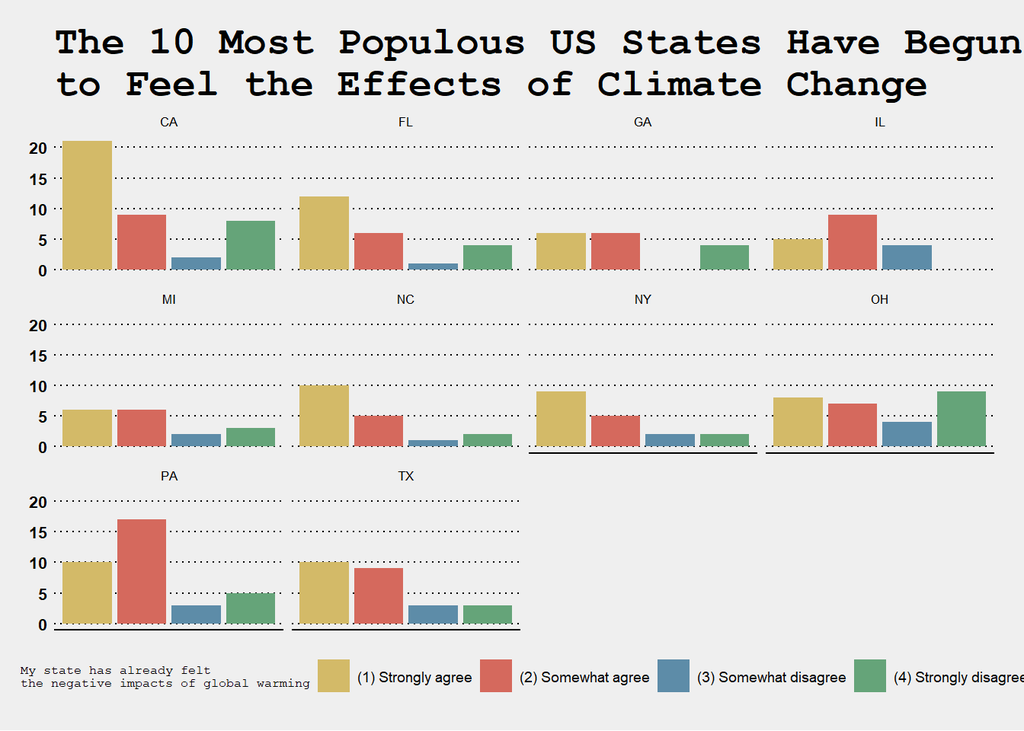

```r
da36368.0001 %>% select(STATE_IMPACTSFELT, DEMOG_STATE) %>%
  filter(!is.na(STATE_IMPACTSFELT)) %>%
  filter(DEMOG_STATE %in% c("CA", "FL", "IL", "GA", "MI", "NC", "NY", "OH", "PA", "TX")) %>%
  ggplot(aes(x = STATE_IMPACTSFELT,
             fill = STATE_IMPACTSFELT)) +
  geom_bar(stat = "count", position = "dodge") + facet_wrap(~DEMOG_STATE) +
  scale_fill_wsj(palette = "rgby", name = "My state has already felt \nthe negative impacts of global warming") +
    theme_wsj(base_size = 8, color = 'gray', base_family = "sans", title_family = "mono") +
  theme(axis.text.x=element_blank(), axis.ticks.x=element_blank(), legend.position = "bottom",
legend.text = element_text(size = 7), legend.title = element_text(size = 6)) +
  labs(title="The 10 Most Populous US States Have Begun \nto Feel the Effects of Climate Change")
```

I chose to graph the current effects of climate change in the most populous states because they had the most data points to compare and show the different impacts based on region. I separated states and graphed the data as a bar chart to more clearly compare responses within the state and between states.

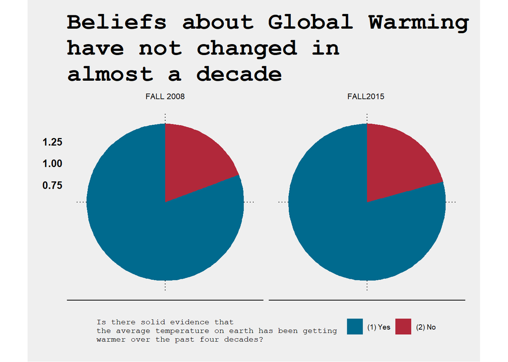

```r
da36368.0001 %>%
  select(GW_BELIEF, SURVEY_ITERATION) %>%
  filter(!is.na(GW_BELIEF)) %>%
ggplot(aes(x = 1,
           fill = GW_BELIEF)) +
  geom_bar(position = "fill") +
  coord_polar(theta = "y") +
  facet_wrap(~SURVEY_ITERATION) +
  scale_fill_wsj(palette = "dem_rep", name = "Is there solid evidence that \nthe average temperature on earth has been getting \nwarmer over the past four decades?") +
  theme_wsj(base_size = 10, color = 'gray', base_family = "sans", title_family = "mono") + theme(axis.text.x=element_blank(), axis.ticks.x=element_blank(), legend.position = "bottom",
legend.text = element_text(size = 7), legend.title = element_text(size = 8)) +
  labs(title = "Beliefs about Global Warming \nhave not changed in \nalmost a decade", x = "Year", y = NULL)
```

I decided to graph two contrasting pie charts to compare opinions about the reality of global warming to demonstrate that there has been virtually no change over almost a decade in the amount of people who believe that there is convincing evidence of climate change. I thought the subtle association to political party with the color scheme in the pie charts would make people think about political motivations to respond this way, even though it isn’t demonstrated in this graph.

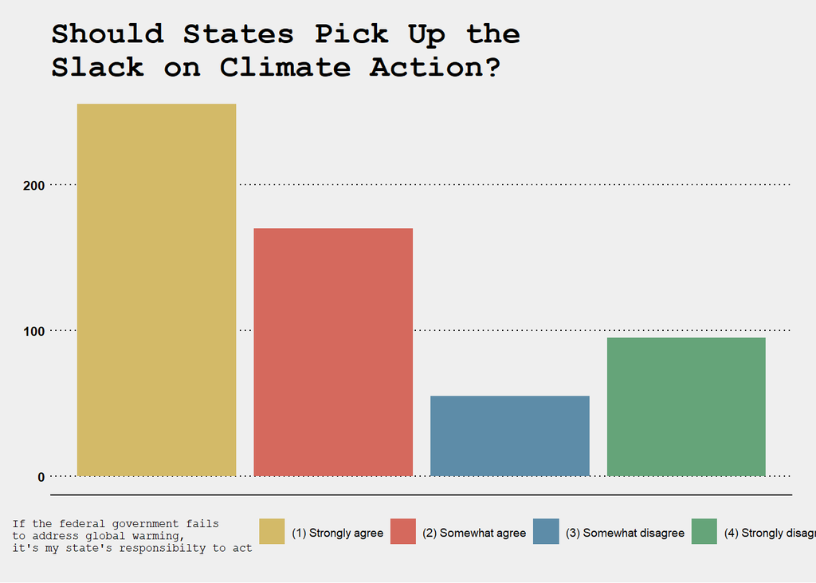

```r
da36368.0001 %>% filter(!is.na(GOVT_NOSTATEACTION)) %>%
  ggplot(aes(x = GOVT_NOSTATEACTION, fill = GOVT_NOSTATEACTION)) + geom_bar() +
  scale_fill_wsj(palette = "rgby",
  name = "If the federal government fails \nto address global warming, \nit's my state's responsibilty to act") +
  theme_wsj(base_size = 8, color = 'gray', base_family = "sans", title_family = "mono") +
  theme(axis.text.x=element_blank(), axis.ticks.x=element_blank(),
        legend.text = element_text(size = 7), legend.title = element_text(size = 7), legend.position = "bottom") +
  labs(title="Should States Pick Up the \nSlack on Climate Action?")
```

I had wanted to graph people’s responses to which level of government had most responsibility for climate action, but wasn’t able to figure it out, so I decided to graph people’s opinions of the state’s responsibilty for climate action if the federal government does not act. This is interesting because the current administration has dangerously backwards stances on climate and has attacked states that have acted independently to solve climate issues. I used geom_bar to compare responses because it was the most visually compelling.